# data607_project2

karmaGyatso

2022-10-09

```r
library(tidyr)
library(dplyr)
```

```r
library(ggplot2)
library(stringr)
```

The data is taken from [Pro Football Reference](https://www.pro-football-reference.com/years/2022/#AFC) and it is in wide format. Even though the dataset has win-loss column but it doesnt clarifies what it means. So I’m cleaning the column with correct values and changing the column names for clarification.

```r
uncleaned_nfl <- read.csv("https://raw.githubusercontent.com/karmaggyatso/CUNY_SPS/main/Github_data607/project2_cleaning_data/unclean_nfl.csv")
uncleaned_nfl
```

```
##                      Tm W L T  W.L.  PF  PA  PD  MoV  SoS   SRS  OSRS DSRS
## 1         Buffalo Bills 3 1 0 0.750 114  58  56 14.0  2.8  16.8   4.9 11.9
## 2        Miami Dolphins 3 1 0 0.750  98  91   7  1.8  8.5  10.2   6.8  3.4
## 3         New York Jets 2 2 0 0.500  76 101 -25 -6.3  3.1  -3.1  -3.6  0.5
## 4  New England Patriots 1 3 0 0.250  74  98 -24 -6.0  5.3  -0.7  -2.7  2.0
## 5      Baltimore Ravens 2 2 0 0.500 119 100  19  4.8  5.8  10.5  12.4 -1.9
## 6    Cincinnati Bengals 2 2 0 0.500  91  70  21  5.3  2.0   7.2   2.9  4.4
## 7      Cleveland Browns 2 2 0 0.500 105  95  10  2.5 -4.2  -1.7   3.6 -5.3
## 8   Pittsburgh Steelers 1 3 0 0.250  74  90 -16 -4.0  0.4  -3.6  -2.9 -0.7
## 9  Jacksonville Jaguars 2 2 0 0.500 105  67  38  9.5  1.6  11.1   9.1  2.0
## 10     Tennessee Titans 2 2 0 0.500  75 101 -26 -6.5  0.0  -6.5  -0.6 -5.9
## 11   Indianapolis Colts 2 2 1 0.500  69  94 -25 -5.0 -1.6  -6.6 -11.9  5.3
## 12       Houston Texans 0 3 1 0.125  73  93 -20 -5.0 -6.2 -11.2  -1.6 -9.6
## 13   Kansas City Chiefs 3 1 0 0.750 129  96  33  8.3 -2.8   5.5  13.8 -8.3
## 14 Los Angeles Chargers 2 2 0 0.500  92 108 -16 -4.0 -0.5  -4.5  -4.8  0.3
## 15       Denver Broncos 2 3 0 0.400  75  80  -5 -1.0 -6.6  -7.6  -9.6  1.9
## 16    Las Vegas Raiders 1 3 0 0.250  96 100  -4 -1.0 -6.4  -7.4   0.9 -8.2
```

In this section I am renaming all the variable name so that it is easier to understand the columns

```r
colnames(uncleaned_nfl) <- c('teams', 'win', 'loss', 'tie', 'win-loss', 'teamScore', 'opponentScore', 'scoreDiff', 'marginVictory', 'strengthScheduel', 'simpleRatingSys', 'offensiveSRS', 'defensiveSRS')
```

I have added few more columns like total_game and win_percent with correct representation. **Select(-c(`win-loss`))** dropping the column win-loss from the original dataset **select(teams, win, loss, tie, total_game, win_percent, everything())**: over here I’m rearranging the column order

```r
clean_nfl <- uncleaned_nfl %>%
  mutate(total_game = win + loss) %>%
  mutate(win_percent = (win/total_game)*100) %>%
  select(-c(`win-loss`)) %>%
  select(teams, win, loss, tie, total_game, win_percent, everything())

clean_nfl
```

```
##                   teams win loss tie total_game win_percent teamScore
## 1         Buffalo Bills   3    1   0          4          75       114
## 2        Miami Dolphins   3    1   0          4          75        98
## 3         New York Jets   2    2   0          4          50        76
## 4  New England Patriots   1    3   0          4          25        74
## 5      Baltimore Ravens   2    2   0          4          50       119
## 6    Cincinnati Bengals   2    2   0          4          50        91
## 7      Cleveland Browns   2    2   0          4          50       105
## 8   Pittsburgh Steelers   1    3   0          4          25        74
## 9  Jacksonville Jaguars   2    2   0          4          50       105
## 10     Tennessee Titans   2    2   0          4          50        75
## 11   Indianapolis Colts   2    2   1          4          50        69
## 12       Houston Texans   0    3   1          3           0        73
## 13   Kansas City Chiefs   3    1   0          4          75       129
## 14 Los Angeles Chargers   2    2   0          4          50        92
```

[output cut: 36 more lines]

## Analysis

I used geom_col to graph the data and the visualization represents the maximum and minumum win% of a team.

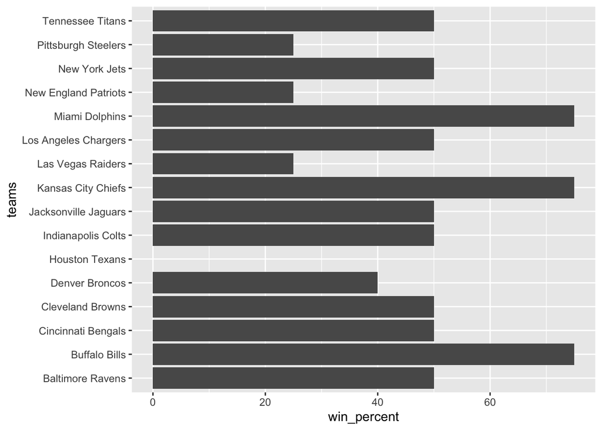

```r
ggplot(clean_nfl, aes(x= teams, y = win_percent)) +
  geom_col(position = 'dodge') +
  #scale_y_continuous(labels = percent) +
  coord_flip()
```

### Student Records

A dataset of students with their score in each term. The dataframe is in wider format and there are empty rows which needs to be deleted.

```r
uncleaned_student_records <- read.csv('https://raw.githubusercontent.com/karmaggyatso/CUNY_SPS/main/Github_data607/project2_cleaning_data/unclean_student_records.csv')
```

in this section, column sex_age is splitted into two column, which are **sex and age**, with their respective values. Also, gathering the term.1, term.2 and term.3 column into single column called term and its values are stored in column **score**

```r
student_exam_df <- uncleaned_student_records |>
  drop_na() |>
  separate(sex.and.age, into = c('sex', 'age'), sep = '_') |>
  pivot_longer(cols = c('term.1', 'term.2', 'term.3'), names_to = 'term', values_to = 'score')
```

In this section, I am extracting all on the numbers of the columns and avoiding the characters.

```r
student_exam_df$term <- str_extract(student_exam_df$term, '\\d')
student_exam_df$test.number <- str_extract(student_exam_df$test.number, '\\d')

student_exam_df
```

```
## # A tibble: 60 × 8
##       id name   phone sex   age   test.number term  score
##    <int> <chr>  <int> <chr> <chr> <chr>       <chr> <int>
##  1     1 Mike     134 m     12    1           1        76
##  2     1 Mike     134 m     12    1           2        84
##  3     1 Mike     134 m     12    1           3        87
##  4     2 Linda    270 f     13    1           1        88
##  5     2 Linda    270 f     13    1           2        90
##  6     2 Linda    270 f     13    1           3        73
##  7     3 Sam      210 m     11    1           1        78
##  8     3 Sam      210 m     11    1           2        74
##  9     3 Sam      210 m     11    1           3        80
## 10     4 Esther   617 f     12    1           1        68
## # … with 50 more rows
## # ℹ Use `print(n = ...)` to see more rows
```

in this section, I have averaged the score of student’s name and term. I have used .groups = ‘drops’ because in my version of R, 4.2.1, it looks like multiple grouping is not supported.

```r
avg_df <- student_exam_df |>
  group_by(name, term) |>
  summarise(avg = mean(score), .groups = 'drop')

head(avg_df)
```

```
## # A tibble: 6 × 3
##   name   term    avg
##   <chr>  <chr> <dbl>
## 1 Dan    1      84.5
## 2 Dan    2      74
## 3 Dan    3      89.5
## 4 Esther 1      69
## 5 Esther 2      75
## 6 Esther 3      76
```

### Admission Records based on gender

```r
uncleaned_admission_df <- read.csv('https://raw.githubusercontent.com/karmaggyatso/CUNY_SPS/main/Github_data607/project2_cleaning_data/unclean_admission.csv')

uncleaned_admission_df
```

```
##    Gender Dept Admitted Rejected
## 1    Male    A      512      313
## 2  Female    A       89       19
## 3    Male    B      353      207
## 4  Female    B       17        8
## 5    Male    C      120      205
## 6  Female    C      202      391
## 7    Male    D      138      279
## 8  Female    D      131      244
## 9    Male    E       53      138
## 10 Female    E       94      299
## 11   Male    F       22      351
## 12 Female    F       24      317
```

```r
admin_gender_df <- uncleaned_admission_df |>
  pivot_longer(cols = c('Admitted', 'Rejected'), names_to = 'status', values_to = 'total')

admin_gender_df
```

```
## # A tibble: 24 × 4
##    Gender Dept  status   total
##    <chr>  <chr> <chr>    <int>
##  1 Male   A     Admitted   512
##  2 Male   A     Rejected   313
##  3 Female A     Admitted    89
##  4 Female A     Rejected    19
##  5 Male   B     Admitted   353
##  6 Male   B     Rejected   207
##  7 Female B     Admitted    17
##  8 Female B     Rejected     8
##  9 Male   C     Admitted   120
## 10 Male   C     Rejected   205
## # … with 14 more rows
## # ℹ Use `print(n = ...)` to see more rows
```

```r
admin_gender_df |>
  group_by(Gender) |>
  summarise(total_application = sum(total))
```

```
## # A tibble: 2 × 2
##   Gender total_application
##   <chr>              <int>
## 1 Female              1835
## 2 Male                2691
```

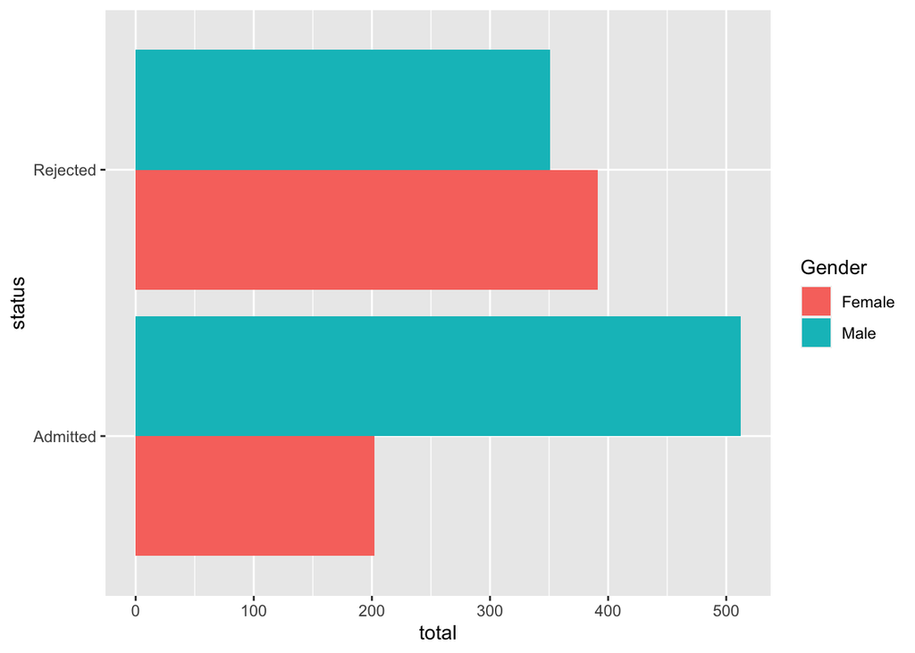

```r
ggplot(admin_gender_df, aes(x=status, y = total, fill=Gender)) +
  geom_col(position = 'dodge')+
  coord_flip()
```